# Reproducible Research: Peer Assessment 1

## Loading and preprocessing the data

Load the `plyr` and `lattice` packages, load the data, and change the class of date column to `Date`:

```r
library(plyr)
library(lattice)

activity <- read.csv('activity.csv')
activity$date <- as.Date(activity$date,'%Y-%m-%d')
```

## What is mean total number of steps taken per day?

Barplot of the total number of steps taken each day:

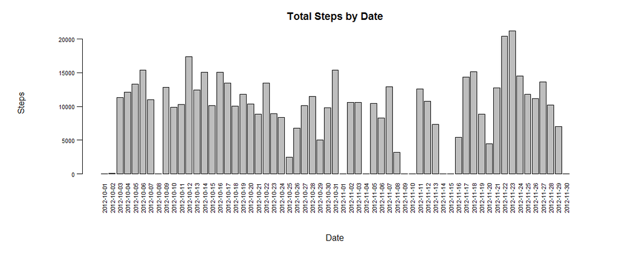

```r
stepsByDate <- ddply(activity, .(date), summarize, totalSteps=sum(steps,na.rm=TRUE))

with(stepsByDate, {
    par(cex.axis=.7,oma=c(1,1,0,0), mar=c(7,7,3,3), mgp=c(5.5,0.75,0),las=2)
    barplot(totalSteps, names.arg=date,
        main="Total Steps by Date",
        xlab="Date",
        ylab="Steps",
        )
    }
)
```

Mean and median of the total number of steps taken per day:

```r
mean(stepsByDate$totalSteps)
```

```
## [1] 9354.23
```

```r
median(stepsByDate$totalSteps)
```

```
## [1] 10395
```

The mean and median of the total number of steps taken per day are 9354.2295082 and 10395, respectively.

## What is the average daily activity pattern?

Time series plot of the number of steps taken, by interval and averaged accross all days:

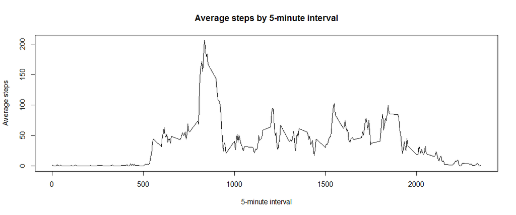

```r
avgStepsByInterval <- ddply(activity, .(interval), summarize, avgSteps=mean(steps,na.rm=TRUE))
with(avgStepsByInterval, {
    plot(interval, avgSteps,
        type='l',
        main='Average steps by 5-minute interval',
        xlab='5-minute interval',
        ylab='Average steps')
    }
)
```

5-minute interval containing the maximum average number of steps:

```r
avgStepsByInterval$interval[which.max(avgStepsByInterval$avgSteps)]
```

```
## [1] 835
```

## Imputing missing values

Total number of missing step values:

```r
sum(is.na(activity$steps))
```

```
## [1] 2304
```

For the missing step values, we impute the data by using the mean number of steps of the corresponding 5-minute time interval. We will use the results in `avgStepsByInterval` from the previous section:

```r
missingIndex <- which(is.na(activity$steps))
imputed <- join(activity[missingIndex,], avgStepsByInterval, "interval", match="first")$avgSteps
activityImputed <- activity
activityImputed$steps[missingIndex] <- imputed
```

Barplot of the total number of steps taken each day, using the imputed dataset:

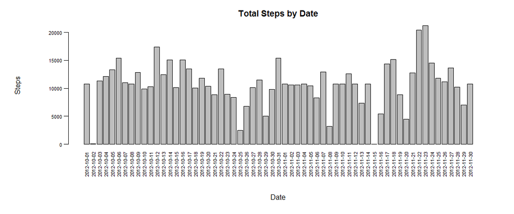

```r
stepsByDateImputed <- ddply(activityImputed, .(date), summarize, totalSteps=sum(steps,na.rm=TRUE))
with(stepsByDateImputed, {
    par(cex.axis=.7,oma=c(1,1,0,0), mar=c(7,7,3,3), mgp=c(5.5,0.75,0),las=2)
    barplot(totalSteps, names.arg=date,
        main="Total Steps by Date",
        xlab="Date",
        ylab="Steps",
        )
    }
)
```

Mean and median of the total number of steps taken per day, using the imputed dataset:

```r
mean(stepsByDateImputed$totalSteps)
```

```
## [1] 10766.19
```

```r
median(stepsByDateImputed$totalSteps)
```

```
## [1] 10766.19
```

## Are there differences in activity patterns between weekdays and weekends?

Create a new factor variable with levels `weekday` and `weekend`:

```r
activityImputed$dayType <- factor(ifelse(weekdays(activityImputed$date) %in% c("Saturday", "Sunday"),
    "weekend",
    "weekday"))
```

Panel plot of time series for the average number of steps taken, by day type:

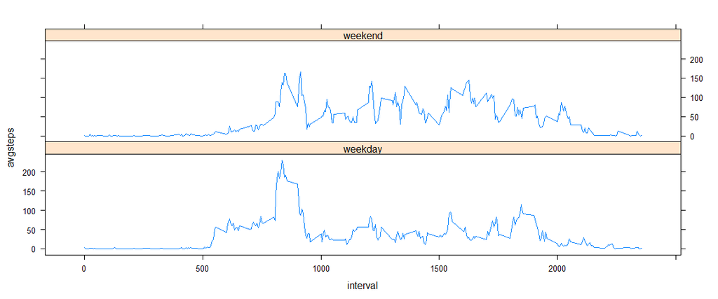

```r
avgStepsByDayTypeInterval <- ddply(activityImputed, .(dayType,interval), summarize, avgsteps=mean(steps,na.rm=TRUE))

xyplot(avgsteps~interval|dayType,avgStepsByDayTypeInterval,type='l',layout=c(1,2))
```